# FEATURISATION & MODEL TUNING

```python
unique_vals = df_new['Pass/Fail'].unique()  # [0, 1, 2]
targets = [df_new.loc[df_new['Pass/Fail'] == val] for val in unique_vals]
```

[output not shown]

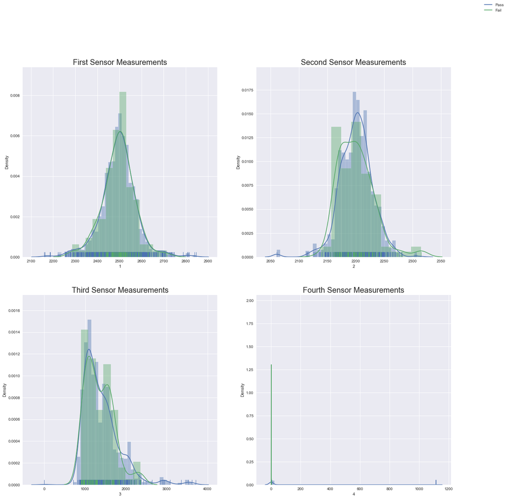

```python
fig = plt.figure(figsize=(20,20))

plt.subplot(2, 2, 1)
for target in targets:
    sns.distplot(target['1'], hist=True, rug=True)
plt.title('First Sensor Measurements', fontsize = 20)

plt.subplot(2, 2, 2)
for target in targets:
    sns.distplot(target['2'], hist=True, rug=True)
plt.title('Second Sensor Measurements', fontsize = 20)

plt.subplot(2, 2, 3)
for target in targets:
    sns.distplot(target['3'], hist=True, rug=True)
plt.title('Third Sensor Measurements', fontsize = 20)

plt.subplot(2, 2, 4)
for target in targets:
    sns.distplot(target['4'], hist=True, rug=True)
plt.title('Fourth Sensor Measurements', fontsize = 20)

#sns.add_legend()
#plt.legend()
fig.legend(labels=['Pass','Fail'])
plt.show()
```

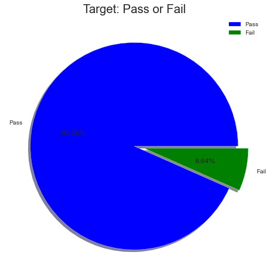

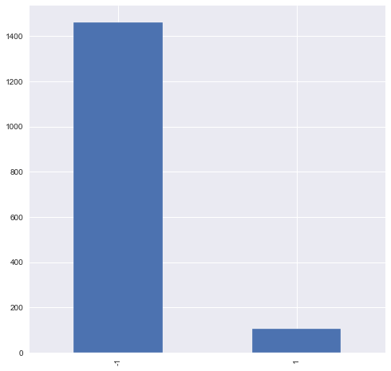

```python
# pie chart
# We have highly imbalanced class with only 6.6% failures and 93.4% pass

labels = ['Pass', 'Fail']
size = df_new['Pass/Fail'].value_counts()
colors = ['blue', 'green']
explode = [0, 0.1]

plt.style.use('seaborn-deep')
plt.rcParams['figure.figsize'] = (8, 8)
plt.pie(size, labels =labels, colors = colors, explode = explode, autopct = "%.2f%%", shadow = True)
plt.axis('off')
plt.title('Target: Pass or Fail', fontsize = 20)
plt.legend()
plt.show()
df_new['Pass/Fail'].value_counts().plot(kind="bar");
```

```python
data
```

[output not shown]

[output cut: 195 more lines]

[output not shown]

```python
#Remove the highly collinear features from data
def remove_collinear_features(x, threshold):
    '''
    Objective:
        Remove collinear features in a dataframe with a correlation coefficient
        greater than the threshold. Removing collinear features can help a model
        to generalize and improves the interpretability of the model.

    Inputs:
        x: features dataframe
        threshold: features with correlations greater than this value are removed

    Output:
        dataframe that contains only the non-highly-collinear features
    '''

    # Calculate the correlation matrix
    corr_matrix = x.corr()
    iters = range(len(corr_matrix.columns) - 1)
    drop_cols = []

    # Iterate through the correlation matrix and compare correlations
    for i in iters:
        for j in range(i+1):
            item = corr_matrix.iloc[j:(j+1), (i+1):(i+2)]
            col = item.columns
            row = item.index
            val = abs(item.values)

            # If correlation exceeds the threshold
            if val >= threshold:
                # Print the correlated features and the correlation value
                print(col.values[0], "|", row.values[0], "|", round(val[0][0], 2))
                drop_cols.append(col.values[0])

    # Drop one of each pair of correlated columns
    drops = set(drop_cols)
    x = x.drop(columns=drops)

    return x
```

```python
#Remove columns having more than 70% correlation
#Both positive and negative correlations are considered here
data = remove_collinear_features(df_new,0.70)
```

```
17 | 11 | 0.79
22 | 21 | 0.73
26 | 25 | 0.82
27 | 25 | 0.98
27 | 26 | 0.79
30 | 29 | 0.86
34 | 32 | 0.75
35 | 34 | 0.77
36 | 32 | 0.75
36 | 34 | 1.0
36 | 35 | 0.77
39 | 34 | 0.8
39 | 36 | 0.8
46 | 45 | 0.81
50 | 46 | 0.9
```

[output cut: 744 more lines]

```python
data
```

|  | 0 | 1 | 2 | 3 | 4 | 5 | 6 | 7 | 8 | 9 | ... | 565 | 570 | 571 | 572 | 582 | 583 | 586 | 587 | 589 | Pass/Fail |
| --- | --- | --- | --- | --- | --- | --- | --- | --- | --- | --- | --- | --- | --- | --- | --- | --- | --- | --- | --- | --- | --- |
| 0 | 3030.93 | 2564.00 | 2187.7333 | 1411.1265 | 1.3602 | 100.0 | 97.6133 | 0.1242 | 1.500500 | 0.016200 | ... | 0.14561 | 533.8500 | 2.1113 | 8.95 | 0.5005 | 0.0118 | 0.021458 | 0.016475 | 99.670066 | -1 |
| 1 | 3095.78 | 2465.14 | 2230.4222 | 1463.6606 | 0.8294 | 100.0 | 102.3433 | 0.1247 | 1.496600 | -0.000500 | ... | 0.14561 | 535.0164 | 2.4335 | 5.92 | 0.5019 | 0.0223 | 0.009600 | 0.020100 | 208.204500 | -1 |
| 2 | 2932.61 | 2559.94 | 2186.4111 | 1698.0172 | 1.5102 | 100.0 | 95.4878 | 0.1241 | 1.443600 | 0.004100 | ... | 0.62190 | 535.0245 | 2.0293 | 11.21 | 0.4958 | 0.0157 | 0.058400 | 0.048400 | 82.860200 | 1 |
| 3 | 2988.72 | 2479.90 | 2199.0333 | 909.7926 | 1.3204 | 100.0 | 104.2367 | 0.1217 | 1.488200 | -0.012400 | ... | 0.16300 | 530.5682 | 2.0253 | 9.33 | 0.4990 | 0.0103 | 0.020200 | 0.014900 | 73.843200 | -1 |
| 4 | 3032.24 | 2502.87 | 2233.3667 | 1326.5200 | 1.5334 | 100.0 | 100.3967 | 0.1235 | 1.503100 | -0.003100 | ... | 0.14561 | 532.0155 | 2.0275 | 8.83 | 0.4800 | 0.4766 | 0.020200 | 0.014900 | 73.843200 | -1 |
| ... | ... | ... | ... | ... | ... | ... | ... | ... | ... | ... | ... | ... | ... | ... | ... | ... | ... | ... | ... | ... | ... |
| 1562 | 2899.41 | 2464.36 | 2179.7333 | 3085.3781 | 1.4843 | 100.0 | 82.2467 | 0.1248 | 1.342400 | -0.004500 | ... | 0.08770 | 536.3418 | 2.0153 | 7.98 | 0.4988 | 0.0143 | 0.006800 | 0.013800 | 203.172000 | -1 |
| 1563 | 3052.31 | 2522.55 | 2198.5667 | 1124.6595 | 0.8763 | 100.0 | 98.4689 | 0.1205 | 1.433300 | -0.006100 | ... | 0.13080 | 537.9264 | 2.1814 | 5.48 | 0.4975 | 0.0131 | 0.006800 | 0.013800 | 203.172000 | -1 |
| 1564 | 2978.81 | 2379.78 | 2206.3000 | 1110.4967 | 0.8236 | 100.0 | 99.4122 | 0.1208 | 1.462862 | -0.000841 | ... | 0.23880 | 530.3709 | 2.3435 | 6.49 | 0.4987 | 0.0153 | 0.019700 | 0.008600 | 43.523100 | -1 |
| 1565 | 2894.92 | 2532.01 | 2177.0333 | 1183.7287 | 1.5726 | 100.0 | 98.7978 | 0.1213 | 1.462200 | -0.007200 | ... | 0.08770 | 534.3936 | 1.9098 | 9.13 | 0.5004 | 0.0178 | 0.026200 | 0.024500 | 93.494100 | -1 |
| 1566 | 2944.92 | 2450.76 | 2195.4444 | 2914.1792 | 1.5978 | 100.0 | 85.1011 | 0.1235 | 1.462862 | -0.000841 | ... | 0.13070 | 528.7918 | 2.0831 | 6.81 | 0.4987 | 0.0181 | 0.011700 | 0.016200 | 137.784400 | -1 |

1567 rows × 318 columns

```
                                3.Data analysis & visualisation:
```

#### A.Perform a detailed univariate Analysis with appropriate detailed comments after each analysis.

#### B.Perform bivariate and multivariate analysis with appropriate detailed comments after each analysis.

```python
stats = data.describe()
```

```python
stats
```

|  | 0 | 1 | 2 | 3 | 4 | 5 | 6 | 7 | 8 | 9 | ... | 565 | 570 | 571 | 572 | 582 | 583 | 586 | 587 | 589 | Pass/Fail |
| --- | --- | --- | --- | --- | --- | --- | --- | --- | --- | --- | --- | --- | --- | --- | --- | --- | --- | --- | --- | --- | --- |
| count | 1567.000000 | 1567.000000 | 1567.000000 | 1567.000000 | 1567.000000 | 1567.0 | 1567.000000 | 1567.000000 | 1567.000000 | 1567.000000 | ... | 1567.000000 | 1567.000000 | 1567.000000 | 1567.000000 | 1567.000000 | 1567.000000 | 1567.000000 | 1567.000000 | 1567.000000 | 1567.000000 |
| mean | 3014.452896 | 2495.850231 | 2200.547318 | 1396.376627 | 4.197013 | 100.0 | 101.112908 | 0.121822 | 1.462862 | -0.000841 | ... | 0.145610 | 530.523623 | 2.101836 | 28.450165 | 0.500096 | 0.015318 | 0.021458 | 0.016475 | 99.670066 | -0.867262 |
| std | 73.480613 | 80.227793 | 29.380932 | 439.712852 | 56.103066 | 0.0 | 6.209271 | 0.008936 | 0.073849 | 0.015107 | ... | 0.073713 | 17.499736 | 0.275112 | 86.304681 | 0.003403 | 0.017174 | 0.012354 | 0.008805 | 93.861936 | 0.498010 |
| min | 2743.240000 | 2158.750000 | 2060.660000 | 0.000000 | 0.681500 | 100.0 | 82.131100 | 0.000000 | 1.191000 | -0.053400 | ... | 0.022400 | 317.196400 | 0.980200 | 3.540000 | 0.477800 | 0.006000 | -0.016900 | 0.003200 | 0.000000 | -1.000000 |
| 25% | 2966.665000 | 2452.885000 | 2181.099950 | 1083.885800 | 1.017700 | 100.0 | 97.937800 | 0.121100 | 1.411250 | -0.010800 | ... | 0.087700 | 530.702700 | 1.982900 | 7.500000 | 0.497900 | 0.011600 | 0.013450 | 0.010600 | 44.368600 | -1.000000 |
| 50% | 3011.840000 | 2498.910000 | 2200.955600 | 1287.353800 | 1.317100 | 100.0 | 101.492200 | 0.122400 | 1.461600 | -0.001300 | ... | 0.142800 | 532.398200 | 2.118600 | 8.650000 | 0.500200 | 0.013800 | 0.020500 | 0.014800 | 72.023000 | -1.000000 |
| 75% | 3056.540000 | 2538.745000 | 2218.055500 | 1590.169900 | 1.529600 | 100.0 | 104.530000 | 0.123800 | 1.516850 | 0.008400 | ... | 0.166850 | 534.356400 | 2.290650 | 10.130000 | 0.502350 | 0.016500 | 0.027600 | 0.020300 | 114.749700 | -1.000000 |
| max | 3356.350000 | 2846.440000 | 2315.266700 | 3715.041700 | 1114.536600 | 100.0 | 129.252200 | 0.128600 | 1.656400 | 0.074900 | ... | 0.689200 | 589.508200 | 2.739500 | 454.560000 | 0.509800 | 0.476600 | 0.102800 | 0.079900 | 737.304800 | 1.000000 |

8 rows × 318 columns

The above output prints the important summary statistics of all the numeric variables like the mean, median (50%), minimum, and maximum values, along with the standard deviation. We can see that certain features are reduntant like "5" , "13" because here all values are 100 and 0 resepectively. Pass/fail is the target feature Most of the features have float values in different ranges. We will plot separate graphs to understand them

```python
std = data.std(axis = 0)
```

```python
std[std == 0].shape
```

```
(116,)
```

There are 116 feature having the same value for all rows.

```python
zero_std = std[std == 0]
col_to_drop = zero_std.index.tolist()
```

```python
non_zero_std_data = data.drop(columns= col_to_drop, axis =1)
non_zero_std_data.shape
```

```
(1567, 202)
```

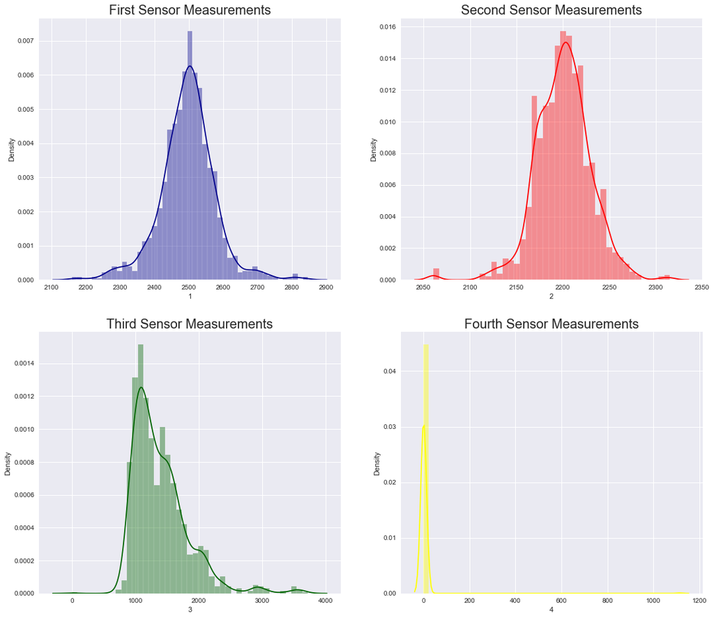

```python
# distribution plot to see first four column's distribution

plt.rcParams['figure.figsize'] = (18, 16)

plt.subplot(2, 2, 1)
sns.distplot(data['1'], color = 'darkblue')
plt.title('First Sensor Measurements', fontsize = 20)

plt.subplot(2, 2, 2)
sns.distplot(data['2'], color = 'red')
plt.title('Second Sensor Measurements', fontsize = 20)

plt.subplot(2, 2, 3)
sns.distplot(data['3'], color = 'darkgreen')
plt.title('Third Sensor Measurements', fontsize = 20)

plt.subplot(2, 2, 4)
sns.distplot(data['4'], color = 'yellow')
plt.title('Fourth Sensor Measurements', fontsize = 20)

plt.show()
```

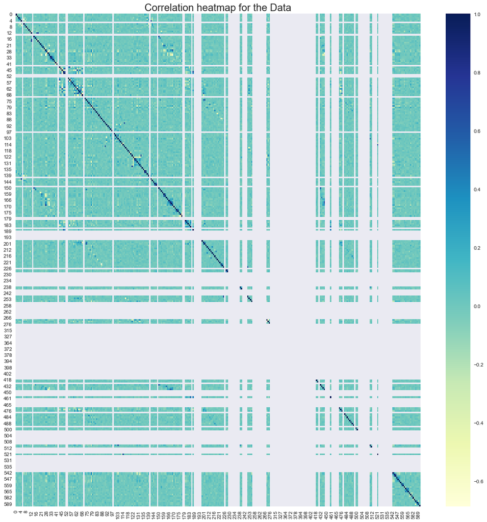

```python
# heatmap to get correlation

plt.rcParams['figure.figsize'] = (18, 18)
sns.heatmap(data.corr(), cmap = "YlGnBu")
plt.title('Correlation heatmap for the Data', fontsize = 20)
```

There are too many feature hence bivarite plot is messy. We do see black color in non-diagonal places which tells us that there are correlated features

```python
data
```

|  | 0 | 1 | 2 | 3 | 4 | 5 | 6 | 7 | 8 | 9 | ... | 565 | 570 | 571 | 572 | 582 | 583 | 586 | 587 | 589 | Pass/Fail |
| --- | --- | --- | --- | --- | --- | --- | --- | --- | --- | --- | --- | --- | --- | --- | --- | --- | --- | --- | --- | --- | --- |
| 0 | 3030.93 | 2564.00 | 2187.7333 | 1411.1265 | 1.3602 | 100.0 | 97.6133 | 0.1242 | 1.500500 | 0.016200 | ... | 0.14561 | 533.8500 | 2.1113 | 8.95 | 0.5005 | 0.0118 | 0.021458 | 0.016475 | 99.670066 | -1 |
| 1 | 3095.78 | 2465.14 | 2230.4222 | 1463.6606 | 0.8294 | 100.0 | 102.3433 | 0.1247 | 1.496600 | -0.000500 | ... | 0.14561 | 535.0164 | 2.4335 | 5.92 | 0.5019 | 0.0223 | 0.009600 | 0.020100 | 208.204500 | -1 |
| 2 | 2932.61 | 2559.94 | 2186.4111 | 1698.0172 | 1.5102 | 100.0 | 95.4878 | 0.1241 | 1.443600 | 0.004100 | ... | 0.62190 | 535.0245 | 2.0293 | 11.21 | 0.4958 | 0.0157 | 0.058400 | 0.048400 | 82.860200 | 1 |
| 3 | 2988.72 | 2479.90 | 2199.0333 | 909.7926 | 1.3204 | 100.0 | 104.2367 | 0.1217 | 1.488200 | -0.012400 | ... | 0.16300 | 530.5682 | 2.0253 | 9.33 | 0.4990 | 0.0103 | 0.020200 | 0.014900 | 73.843200 | -1 |
| 4 | 3032.24 | 2502.87 | 2233.3667 | 1326.5200 | 1.5334 | 100.0 | 100.3967 | 0.1235 | 1.503100 | -0.003100 | ... | 0.14561 | 532.0155 | 2.0275 | 8.83 | 0.4800 | 0.4766 | 0.020200 | 0.014900 | 73.843200 | -1 |
| ... | ... | ... | ... | ... | ... | ... | ... | ... | ... | ... | ... | ... | ... | ... | ... | ... | ... | ... | ... | ... | ... |
| 1562 | 2899.41 | 2464.36 | 2179.7333 | 3085.3781 | 1.4843 | 100.0 | 82.2467 | 0.1248 | 1.342400 | -0.004500 | ... | 0.08770 | 536.3418 | 2.0153 | 7.98 | 0.4988 | 0.0143 | 0.006800 | 0.013800 | 203.172000 | -1 |
| 1563 | 3052.31 | 2522.55 | 2198.5667 | 1124.6595 | 0.8763 | 100.0 | 98.4689 | 0.1205 | 1.433300 | -0.006100 | ... | 0.13080 | 537.9264 | 2.1814 | 5.48 | 0.4975 | 0.0131 | 0.006800 | 0.013800 | 203.172000 | -1 |
| 1564 | 2978.81 | 2379.78 | 2206.3000 | 1110.4967 | 0.8236 | 100.0 | 99.4122 | 0.1208 | 1.462862 | -0.000841 | ... | 0.23880 | 530.3709 | 2.3435 | 6.49 | 0.4987 | 0.0153 | 0.019700 | 0.008600 | 43.523100 | -1 |
| 1565 | 2894.92 | 2532.01 | 2177.0333 | 1183.7287 | 1.5726 | 100.0 | 98.7978 | 0.1213 | 1.462200 | -0.007200 | ... | 0.08770 | 534.3936 | 1.9098 | 9.13 | 0.5004 | 0.0178 | 0.026200 | 0.024500 | 93.494100 | -1 |
| 1566 | 2944.92 | 2450.76 | 2195.4444 | 2914.1792 | 1.5978 | 100.0 | 85.1011 | 0.1235 | 1.462862 | -0.000841 | ... | 0.13070 | 528.7918 | 2.0831 | 6.81 | 0.4987 | 0.0181 | 0.011700 | 0.016200 | 137.784400 | -1 |

1567 rows × 318 columns

```
                                        4.Data pre-processing
```

#### A.Segregate predictors vs target attributes.

Predictor Variable - One or more variables that are used to determine(Predict) the 'Target Variable'. Target Variable - A variable that needs to be predicted is a target variable. The above quantities are determined prior to the experiment, the person who is conducting the experiment has to come up with a problem statement and once he does, he determines which variables are predictor variables and which one is the target variable. If I find that a variable is not a predictor variable, does that mean it automatically becomes a target variable? No, if you read the description above your question is invalid. Generally, if you have data of very high dimensionality and a target variable, you will have to reduce the number of dimensions (depending upon the scenario) either you will decide to go will all the predictor variables or choose a dimensionality technique such as PCA(Principal Component Analysis). If you choose to perform PCA, you will select handful of predictor variables and drop(remove) the remaining variables, while doing so the Target Variable remains the same.

# separating the dependent and independent data

# getting the shapes of new data sets x and y

```python
# Select independent features for model building. ( ID is dropped)
#X = data.drop(['Pass/Fail', 'Time'], axis=1)
X = data.drop(['Pass/Fail'], axis=1)

y = data['Pass/Fail']

# split data into train subset and test subset
X_train, X_test, y_train, y_test = train_test_split(X, y, test_size=0.3, random_state=42, stratify=y )

# checking the dimensions of the train & test subset
# to print dimension of train set
print(X_train.shape)
# to print dimension of test set
print(X_test.shape)
```

```
(1096, 317)
(471, 317)
```

```python
X_train.head(2)
```

|  | 0 | 1 | 2 | 3 | 4 | 5 | 6 | 7 | 8 | 9 | ... | 564 | 565 | 570 | 571 | 572 | 582 | 583 | 586 | 587 | 589 |
| --- | --- | --- | --- | --- | --- | --- | --- | --- | --- | --- | --- | --- | --- | --- | --- | --- | --- | --- | --- | --- | --- |
| 594 | 3042.70 | 2355.11 | 2242.8555 | 1430.7270 | 0.8832 | 100.0 | 106.2100 | 0.1216 | 1.4817 | 0.0030 | ... | 6.444985 | 0.14561 | 531.4073 | 2.0161 | 8.05 | 0.4937 | 0.0153 | 0.0256 | 0.0189 | 73.8657 |
| 1380 | 3093.31 | 2456.82 | 2207.9555 | 1283.4368 | 1.8467 | 100.0 | 95.4022 | 0.1216 | 1.4198 | -0.0156 | ... | 4.980000 | 0.08770 | 529.8827 | 1.9602 | 11.05 | 0.4988 | 0.0126 | 0.0203 | 0.0134 | 65.9827 |

2 rows × 317 columns

# splitting them into train test and split

from sklearn.model_selection import train_test_split

# gettiing the shapes

#### B.Check for target balancing and fix it if found imbalanced.

```python
pd.value_counts(data['Pass/Fail'])
```

```
-1    1463
 1     104
Name: Pass/Fail, dtype: int64
```

```python
print("Before OverSampling, counts of label '1': {}".format(sum(y_train==1)))
print("Before OverSampling, counts of label '-1': {} \n".format(sum(y_train==-1)))
```

```
Before OverSampling, counts of label '1': 73
Before OverSampling, counts of label '-1': 1023
```

```python
#data.drop("Time", axis=1)
```

```python
sm = SMOTE(random_state=2)
oversample = SMOTE()
X_train_res, y_train_res = oversample.fit_resample(X_train, y_train.ravel())
#X_train_res, y_train_res = sm.fit_sample(X_train, y_train.ravel())


print('After OverSampling, the shape of train_X: {}'.format(X_train_res.shape))
print('After OverSampling, the shape of train_y: {} \n'.format(y_train_res.shape))
```

```
After OverSampling, the shape of train_X: (2046, 317)
After OverSampling, the shape of train_y: (2046,)
```

```python
pd.value_counts(y_test)
```

```
-1    440
 1     31
Name: Pass/Fail, dtype: int64
```

#### C.Perform train-test split and standardise the data or vice versa if required.

```python
# standardization

from sklearn.preprocessing import StandardScaler

# creating a standard scaler
sc = StandardScaler()

# fitting independent data to the model
x_train_sc = sc.fit_transform(X_train_res)
x_test_sc = sc.transform(X_test)
```

#### D.Check if the train and test data have similar statistical characteristics when compared with original data.

```python
data.describe()
```

|  | 0 | 1 | 2 | 3 | 4 | 5 | 6 | 7 | 8 | 9 | ... | 565 | 570 | 571 | 572 | 582 | 583 | 586 | 587 | 589 | Pass/Fail |
| --- | --- | --- | --- | --- | --- | --- | --- | --- | --- | --- | --- | --- | --- | --- | --- | --- | --- | --- | --- | --- | --- |
| count | 1567.000000 | 1567.000000 | 1567.000000 | 1567.000000 | 1567.000000 | 1567.0 | 1567.000000 | 1567.000000 | 1567.000000 | 1567.000000 | ... | 1567.000000 | 1567.000000 | 1567.000000 | 1567.000000 | 1567.000000 | 1567.000000 | 1567.000000 | 1567.000000 | 1567.000000 | 1567.000000 |
| mean | 3014.452896 | 2495.850231 | 2200.547318 | 1396.376627 | 4.197013 | 100.0 | 101.112908 | 0.121822 | 1.462862 | -0.000841 | ... | 0.145610 | 530.523623 | 2.101836 | 28.450165 | 0.500096 | 0.015318 | 0.021458 | 0.016475 | 99.670066 | -0.867262 |
| std | 73.480613 | 80.227793 | 29.380932 | 439.712852 | 56.103066 | 0.0 | 6.209271 | 0.008936 | 0.073849 | 0.015107 | ... | 0.073713 | 17.499736 | 0.275112 | 86.304681 | 0.003403 | 0.017174 | 0.012354 | 0.008805 | 93.861936 | 0.498010 |
| min | 2743.240000 | 2158.750000 | 2060.660000 | 0.000000 | 0.681500 | 100.0 | 82.131100 | 0.000000 | 1.191000 | -0.053400 | ... | 0.022400 | 317.196400 | 0.980200 | 3.540000 | 0.477800 | 0.006000 | -0.016900 | 0.003200 | 0.000000 | -1.000000 |
| 25% | 2966.665000 | 2452.885000 | 2181.099950 | 1083.885800 | 1.017700 | 100.0 | 97.937800 | 0.121100 | 1.411250 | -0.010800 | ... | 0.087700 | 530.702700 | 1.982900 | 7.500000 | 0.497900 | 0.011600 | 0.013450 | 0.010600 | 44.368600 | -1.000000 |
| 50% | 3011.840000 | 2498.910000 | 2200.955600 | 1287.353800 | 1.317100 | 100.0 | 101.492200 | 0.122400 | 1.461600 | -0.001300 | ... | 0.142800 | 532.398200 | 2.118600 | 8.650000 | 0.500200 | 0.013800 | 0.020500 | 0.014800 | 72.023000 | -1.000000 |
| 75% | 3056.540000 | 2538.745000 | 2218.055500 | 1590.169900 | 1.529600 | 100.0 | 104.530000 | 0.123800 | 1.516850 | 0.008400 | ... | 0.166850 | 534.356400 | 2.290650 | 10.130000 | 0.502350 | 0.016500 | 0.027600 | 0.020300 | 114.749700 | -1.000000 |
| max | 3356.350000 | 2846.440000 | 2315.266700 | 3715.041700 | 1114.536600 | 100.0 | 129.252200 | 0.128600 | 1.656400 | 0.074900 | ... | 0.689200 | 589.508200 | 2.739500 | 454.560000 | 0.509800 | 0.476600 | 0.102800 | 0.079900 | 737.304800 | 1.000000 |

8 rows × 318 columns

```python
X_train_res_df = pd.DataFrame(X_train_res)
X_train_res_df.describe()
```

|  | 0 | 1 | 2 | 3 | 4 | 5 | 6 | 7 | 8 | 9 | ... | 564 | 565 | 570 | 571 | 572 | 582 | 583 | 586 | 587 | 589 |
| --- | --- | --- | --- | --- | --- | --- | --- | --- | --- | --- | --- | --- | --- | --- | --- | --- | --- | --- | --- | --- | --- |
| count | 2046.000000 | 2046.000000 | 2046.000000 | 2046.000000 | 2046.000000 | 2046.0 | 2046.000000 | 2046.000000 | 2046.000000 | 2046.000000 | ... | 2046.000000 | 2046.000000 | 2046.000000 | 2046.000000 | 2046.000000 | 2046.000000 | 2046.000000 | 2046.000000 | 2046.000000 | 2046.000000 |
| mean | 3006.333907 | 2502.298015 | 2201.506515 | 1387.625004 | 2.424529 | 100.0 | 101.173691 | 0.122032 | 1.469841 | -0.002659 | ... | 6.382747 | 0.156263 | 527.492758 | 2.096218 | 24.535550 | 0.500056 | 0.015700 | 0.022131 | 0.017169 | 101.410586 |
| std | 72.466394 | 71.204063 | 27.852514 | 372.752427 | 34.722711 | 0.0 | 5.446284 | 0.006303 | 0.064045 | 0.013248 | ... | 2.075346 | 0.081443 | 25.804070 | 0.284935 | 67.508852 | 0.003231 | 0.015215 | 0.011593 | 0.008337 | 83.898755 |
| min | 2743.240000 | 2162.870000 | 2060.660000 | 711.025800 | 0.681500 | 100.0 | 82.131100 | 0.000000 | 1.200500 | -0.041000 | ... | 0.970000 | 0.022400 | 317.196400 | 0.980200 | 4.840000 | 0.477800 | 0.006500 | -0.016900 | 0.003200 | 0.000000 |
| 25% | 2956.672834 | 2464.890000 | 2183.739895 | 1111.456525 | 1.088808 | 100.0 | 98.500275 | 0.121196 | 1.429550 | -0.010590 | ... | 4.980000 | 0.098400 | 530.580803 | 1.979347 | 7.770000 | 0.498027 | 0.011972 | 0.015003 | 0.011400 | 49.754107 |
| 50% | 2997.599371 | 2505.714300 | 2199.350737 | 1311.685128 | 1.317158 | 100.0 | 101.232397 | 0.122231 | 1.468644 | -0.002762 | ... | 6.291222 | 0.145610 | 532.234943 | 2.140050 | 8.980000 | 0.500181 | 0.014200 | 0.021323 | 0.015700 | 79.108600 |
| 75% | 3047.257500 | 2538.284810 | 2217.411100 | 1589.307085 | 1.501668 | 100.0 | 103.936700 | 0.123500 | 1.513838 | 0.004494 | ... | 7.189505 | 0.181542 | 534.137950 | 2.288719 | 10.339429 | 0.502100 | 0.016967 | 0.028000 | 0.021197 | 118.293462 |
| max | 3356.350000 | 2846.440000 | 2315.266700 | 3715.041700 | 1112.160000 | 100.0 | 129.252200 | 0.128600 | 1.656400 | 0.060900 | ... | 16.060000 | 0.689200 | 569.996400 | 2.739500 | 445.800000 | 0.509800 | 0.476600 | 0.102800 | 0.079900 | 737.304800 |

8 rows × 317 columns

```python
X_test.describe()
```

|  | 0 | 1 | 2 | 3 | 4 | 5 | 6 | 7 | 8 | 9 | ... | 564 | 565 | 570 | 571 | 572 | 582 | 583 | 586 | 587 | 589 |
| --- | --- | --- | --- | --- | --- | --- | --- | --- | --- | --- | --- | --- | --- | --- | --- | --- | --- | --- | --- | --- | --- |
| count | 471.000000 | 471.000000 | 471.000000 | 471.000000 | 471.000000 | 471.0 | 471.000000 | 471.000000 | 471.000000 | 471.000000 | ... | 471.000000 | 471.000000 | 471.000000 | 471.000000 | 471.000000 | 471.000000 | 471.000000 | 471.000000 | 471.000000 | 471.000000 |
| mean | 3018.147146 | 2492.569492 | 2201.763420 | 1402.650974 | 6.071317 | 100.0 | 101.056154 | 0.121595 | 1.460357 | 0.000168 | ... | 6.509987 | 0.141821 | 532.353208 | 2.102741 | 31.033058 | 0.500242 | 0.014750 | 0.020611 | 0.016849 | 102.869498 |
| std | 75.371915 | 79.245997 | 28.758001 | 455.877662 | 72.396492 | 0.0 | 6.069961 | 0.009932 | 0.073537 | 0.014821 | ... | 2.710850 | 0.067979 | 6.932885 | 0.264066 | 95.187880 | 0.003268 | 0.005406 | 0.011535 | 0.009724 | 94.235121 |
| min | 2792.240000 | 2158.750000 | 2060.660000 | 0.000000 | 0.721700 | 100.0 | 82.131100 | 0.000000 | 1.191000 | -0.053400 | ... | 1.140000 | 0.028900 | 480.529100 | 0.984700 | 3.540000 | 0.491500 | 0.006000 | -0.006000 | 0.003200 | 0.000000 |
| 25% | 2971.895000 | 2451.960000 | 2180.794450 | 1089.365500 | 1.019000 | 100.0 | 97.917800 | 0.120900 | 1.410650 | -0.009950 | ... | 4.980000 | 0.087700 | 530.886350 | 1.994300 | 7.470000 | 0.497950 | 0.011500 | 0.012950 | 0.010450 | 47.072200 |
| 50% | 3014.452896 | 2497.490000 | 2203.166700 | 1283.436800 | 1.299800 | 100.0 | 101.566700 | 0.122200 | 1.458700 | -0.000500 | ... | 5.920000 | 0.131400 | 532.452700 | 2.113000 | 8.640000 | 0.500300 | 0.013900 | 0.019800 | 0.014800 | 72.109400 |
| 75% | 3062.850000 | 2533.855000 | 2219.766700 | 1590.741600 | 1.517400 | 100.0 | 104.601150 | 0.123800 | 1.510850 | 0.008600 | ... | 7.530000 | 0.171350 | 534.269100 | 2.289500 | 10.190000 | 0.502600 | 0.016400 | 0.027400 | 0.020700 | 122.024450 |
| max | 3299.400000 | 2806.910000 | 2306.100000 | 3619.739700 | 1114.536600 | 100.0 | 129.252200 | 0.127600 | 1.653900 | 0.074900 | ... | 32.580000 | 0.493700 | 589.508200 | 2.739500 | 454.560000 | 0.508800 | 0.046000 | 0.079800 | 0.079900 | 737.304800 |

8 rows × 317 columns

```
                                    5.Model training, testing and tuning:
```

#### A.Use any Supervised Learning technique to train a model.

#### B.Use cross validation techniques.Hint: Use all CV techniques that you have learnt in the course.

#### C.Apply hyper-parameter tuning techniques to get the best accuracy.

Suggestion: Use all possible hyper parameter combinations to extract the best accuracies.

#### D.Use any other technique/method which can enhance the model performance.

Hint: Dimensionality reduction, attribute removal, standardisation/normalisation, target balancing etc.

#### E.Display and explain the classification report in detail.

#### F.Apply the above steps for all possible models that you have learnt so far.

```python
from sklearn.linear_model import LogisticRegression

lr = LogisticRegression(random_state=1)
lr.fit(X_train, y_train)
y_pred = lr.predict(X_test)
```

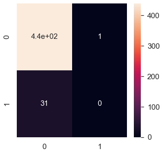

```python
cm = confusion_matrix(y_test, y_pred)
plt.rcParams['figure.figsize'] = (5, 5)
sns.set(style = 'dark', font_scale = 1.4)
sns.heatmap(cm, annot = True, annot_kws = {"size": 15})
```

```python
print("Accuracy: ", lr.score(X_test,y_test)*100)
```

```
Accuracy:  93.20594479830149
```

```python
# Under Sampling - Check how many failure observations are there
# We have 104 such observations

failed_tests = np.array(data[data['Pass/Fail'] == 1].index)
no_failed_tests = len(failed_tests)

print(no_failed_tests)
```

```
104
```

```python
# Check how many pass observations are there
# We have 1,463 such observations

normal_indices = data[data['Pass/Fail'] == -1]
no_normal_indices = len(normal_indices)

print(no_normal_indices)
```

```
1463
```

```python
# Get 104 random observations from the pass class as well

random_normal_indices = np.random.choice(no_normal_indices, size = no_failed_tests, replace = True)
random_normal_indices = np.array(random_normal_indices)

print(len(random_normal_indices))
```

```
104
```

```python
#Getting a 50-50 representation from both pass and fail classes
under_sample = np.concatenate([failed_tests, random_normal_indices])
print(len(under_sample))
```

```
208
```

```python
# creating the undersample data

undersample_data = data.iloc[under_sample, :]
```

```python
# splitting the undersample dataset into x and y sets

x = undersample_data.iloc[:, undersample_data.columns != 'Pass/Fail']
y = undersample_data.iloc[:, undersample_data.columns == 'Pass/Fail']

print(x.shape)
print(y.shape)
```

```
(208, 317)
(208, 1)
```

```python
from sklearn.model_selection import train_test_split

x_train_us, x_test_us, y_train_us, y_test_us = train_test_split(x, y, test_size = 0.3, random_state = 1)

print(x_train_us.shape)
print(y_train_us.shape)
print(x_test_us.shape)
print(y_test_us.shape)
```

```
(145, 317)
(145, 1)
(63, 317)
(63, 1)
```

```python
# standardization

sc = StandardScaler()
x_train_us = sc.fit_transform(x_train_us)
x_test_us = sc.transform(x_test_us)
```

```python
from sklearn.preprocessing import LabelEncoder
le = LabelEncoder()
y_train = le.fit_transform(y_train)
```

```python
xgb_clf1 = XGBClassifier(learning_rate=0.1, n_estimators=50, max_depth=2)
xgb_clf1.fit(x_train_us, y_train_us)
print(xgb_clf1.score(x_train_us, y_train_us))
print(xgb_clf1.score(x_test_us, y_test_us))
```

```
1.0
0.6507936507936508
```

```python
# import function for ridge regression
from sklearn.linear_model import RidgeClassifier

tuned_paramaters = [{'alpha':[7, 8, 9, 10, 11]}]

# instantiate the Ridge() method
ridge = RidgeClassifier()

# use GridSearchCV() to find the optimal value of alpha
# estimator: pass the ridge regression model
# param_grid: pass the list 'tuned_parameters'
# cv: number of folds in k-fold i.e. here cv = 5
ridge_grid = GridSearchCV(estimator = ridge,
                          param_grid = tuned_paramaters,
                          cv = 5)

# fit the model on X_train and y_train using fit()
ridge_grid.fit(x_train_sc, y_train_res)

# get the best parameters
print('Best parameters for Ridge Regression:', ridge_grid.best_params_)
```

```
Best parameters for Ridge Regression: {'alpha': 7}
```

```python
from sklearn.ensemble import RandomForestClassifier

forest = RandomForestClassifier()
forest.fit(x_train_sc, y_train_res)

y_pred_rf = forest.predict(x_test_sc)
print('accuracy score', accuracy_score(y_pred_rf, y_test))
print('confusion_matrix', confusion_matrix(y_pred_rf, y_test))
print('precision_score', average_precision_score(y_pred_rf, y_test))
```

```
accuracy score 0.9320594479830149
confusion_matrix [[439  31]
 [  1   0]]
precision_score 0.0021231422505307855
```

```python
# Applying Grid Search CV to find the best model with the best parameters

from sklearn.model_selection import GridSearchCV
from sklearn.metrics import classification_report

model = RandomForestClassifier(n_estimators= 50, criterion= 'gini')

# making a parameters list
parameters = {
    'max_depth' : [10, 50, 100, 150],
    'min_samples_split': [1, 2, 3],
    'min_samples_leaf': [1, 2, 3]}

# making a grid search model
grid_search = GridSearchCV(estimator = model, param_grid = parameters, scoring = 'f1', cv = 3, n_jobs = -1)
grid_search = grid_search.fit(x_train_sc, y_train_res)

# getting the results
best_accuracy = grid_search.best_score_
best_parameters = grid_search.best_params_

predictions = grid_search.predict(x_test_sc)

print("Best Accuracy: ", best_accuracy)
print("Best Parameter: ", best_parameters)
print(classification_report(y_test, predictions))
```

[output not shown]

```
Best Accuracy:  0.9885490036593602
Best Parameter:  {'max_depth': 100, 'min_samples_leaf': 1, 'min_samples_split': 2}
              precision    recall  f1-score   support

          -1       0.94      1.00      0.97       440
           1       1.00      0.03      0.06        31

    accuracy                           0.94       471
   macro avg       0.97      0.52      0.51       471
weighted avg       0.94      0.94      0.91       471
```

```python
model = RandomForestClassifier(n_estimators= 50, criterion= 'gini', max_depth= 100)
model.fit(x_train_sc, y_train_res)

y_pred_rf = model.predict(x_test_sc)

print('accuracy score', accuracy_score(y_pred_rf, y_test))
print('confusion_matrix', confusion_matrix(y_pred_rf, y_test))
print('precision_score', average_precision_score(y_pred_rf, y_test))
```

```
accuracy score 0.9320594479830149
confusion_matrix [[439  31]
 [  1   0]]
precision_score 0.0021231422505307855
```

```python
#PCA

#Scaling the data before applying PCA
from scipy.stats import zscore
data_new=data.iloc[:,:317].apply(zscore)
data_new.head()
```

|  | 0 | 1 | 2 | 3 | 4 | 5 | 6 | 7 | 8 | 9 | ... | 564 | 565 | 570 | 571 | 572 | 582 | 583 | 586 | 587 | 589 |
| --- | --- | --- | --- | --- | --- | --- | --- | --- | --- | --- | --- | --- | --- | --- | --- | --- | --- | --- | --- | --- | --- |
| 0 | 0.224309 | 0.849725 | -0.436273 | 0.033555 | -0.050580 | NaN | -0.563790 | 0.266269 | 0.509826 | 1.128417 | ... | -3.452799e-14 | 1.544290e-14 | 0.190142 | 0.034410 | -0.226018 | 0.118699 | -0.204890 | -2.528283e-15 | -2.759188e-15 | -1.665950e-15 |
| 1 | 1.107136 | -0.382910 | 1.017137 | 0.153067 | -0.060045 | NaN | 0.198217 | 0.322244 | 0.456999 | 0.022582 | ... | -3.452799e-14 | 1.544290e-14 | 0.256816 | 1.205944 | -0.261137 | 0.530203 | 0.406679 | -9.601744e-01 | 4.118532e-01 | 1.156689e+00 |
| 2 | -1.114158 | 0.799102 | -0.481289 | 0.686213 | -0.047906 | NaN | -0.906210 | 0.255074 | -0.260907 | 0.327183 | ... | -2.234265e+00 | 6.463483e+00 | 0.257279 | -0.263745 | -0.199823 | -1.262780 | 0.022264 | 2.991151e+00 | 3.627063e+00 | -1.791486e-01 |
| 3 | -0.350312 | -0.198875 | -0.051547 | -1.106948 | -0.051290 | NaN | 0.503246 | -0.013602 | 0.343218 | -0.765408 | ... | 3.657665e-01 | 2.359971e-01 | 0.002548 | -0.278290 | -0.221613 | -0.322199 | -0.292257 | -1.018947e-01 | -1.789275e-01 | -2.752459e-01 |
| 4 | 0.242143 | 0.087526 | 1.117387 | -0.158919 | -0.047492 | NaN | -0.115382 | 0.187905 | 0.545044 | -0.149584 | ... | -3.452799e-14 | 1.544290e-14 | 0.085279 | -0.270290 | -0.227409 | -5.906899 | 26.867231 | -1.018947e-01 | -1.789275e-01 | -2.752459e-01 |

5 rows × 317 columns

```python
data_new.isnull().any().any()
```

```
True
```

```python
data_new = data_new.replace(np.NaN, 0)
```

```python
data_new.isnull().any().any()
```

```
False
```

```python
# separating the dependent and independent data

x = data_new.iloc[:,:306]
y = data["Pass/Fail"]

# getting the shapes of new data sets x and y
print("shape of x:", x.shape)
print("shape of y:", y.shape)
```

```
shape of x: (1567, 306)
shape of y: (1567,)
```

```python
# PCA
# Step 1 - Create covariance matrix

cov_matrix = np.cov(x.T)
print('Covariance Matrix \n%s', cov_matrix)
```

```
Covariance Matrix
%s [[ 1.00063857 -0.14393166  0.00475868 ...  0.02919828  0.04144353
  -0.0095894 ]
 [-0.14393166  1.00063857  0.00577089 ... -0.03948186 -0.02772221
   0.03716221]
 [ 0.00475868  0.00577089  1.00063857 ...  0.02992183  0.02849379
   0.01331819]
 ...
 [ 0.02919828 -0.03948186  0.02992183 ...  1.00063857  0.43534538
  -0.0049579 ]
 [ 0.04144353 -0.02772221  0.02849379 ...  0.43534538  1.00063857
  -0.04825569]
 [-0.0095894   0.03716221  0.01331819 ... -0.0049579  -0.04825569
   1.00063857]]
```

```python
# Step 2- Get eigen values and eigen vector
eig_vals, eig_vecs = np.linalg.eig(cov_matrix)
print('Eigen Vectors \n%s', eig_vecs)
print('\n Eigen Values \n%s', eig_vals)
```

```
Eigen Vectors
%s [[ 0.0483261  -0.01106888  0.03306473 ...  0.          0.
   0.        ]
 [-0.00468385 -0.0156867  -0.02840696 ...  0.          0.
   0.        ]
 [-0.00849433 -0.0084747  -0.07343345 ...  0.          0.
   0.        ]
 ...
 [ 0.01816574  0.02336162 -0.01064229 ...  0.          0.
   0.        ]
 [ 0.00246968 -0.00877451 -0.01987599 ...  0.          0.
   0.        ]
 [ 0.05098845  0.0673542  -0.0570457  ...  0.          0.
   0.        ]]

 Eigen Values
%s [7.65052592e+00 4.77109595e+00 3.88576583e+00 3.66703961e+00
 3.38074783e+00 3.14998626e+00 3.04477508e+00 2.79101020e+00
 2.57126724e+00 2.54259971e+00 2.43296456e+00 2.34636888e+00
 2.30599152e+00 2.25736074e+00 2.17884802e+00 2.14446433e+00
 2.09353759e+00 2.06779018e+00 2.04164255e+00 1.99780301e+00
 1.96085697e+00 1.93501444e+00 2.04786244e-04 1.87959367e+00
 1.87316519e+00 1.82441636e+00 1.81891117e+00 1.79217781e+00
 1.74911445e+00 1.73253915e+00 1.70174915e+00 1.69743687e+00
 1.68066270e+00 1.64193241e+00 1.61939179e+00 1.59730974e+00
 1.57338761e+00 1.56542271e+00 1.53207498e+00 1.51431597e+00
 1.49050637e+00 1.47742552e+00 1.44737418e+00 1.41608710e+00
 1.42513151e+00 1.35361369e+00 1.35258359e+00 1.31949715e+00
 5.96439798e-03 2.75831334e-02 3.73690428e-02 1.32712785e+00
 1.30172380e+00 1.29468464e+00 1.27542932e+00 1.25728086e+00
 1.21943346e+00 1.23466216e+00 1.23194054e+00 6.60970377e-02
 6.27844506e-02 8.79754275e-02 1.20347907e+00 1.19190221e+00
 1.18594980e+00 1.16927586e+00 1.14765777e+00 1.12212150e+00
 9.80174564e-02 1.04248961e-01 1.12430343e-01 1.20468142e-01
 1.32711120e-01 1.37055791e-01 1.11079995e+00 1.08688862e+00
 1.10218500e+00 1.46479146e-01 1.08246122e+00 1.06953563e+00
 1.06189676e+00 1.68348545e-01 1.73383003e-01 1.02373180e+00
 1.03035125e+00 1.04879562e+00 1.04807361e+00 1.00201821e+00
 9.84762322e-01 1.82055120e-01 1.89400751e-01 1.98140000e-01
 2.01119128e-01 2.08725731e-01 9.76356475e-01 9.67990437e-01
```

[output cut: 38 more lines]

```
 0.00000000e+00 0.00000000e+00 0.00000000e+00 0.00000000e+00
 0.00000000e+00 0.00000000e+00 0.00000000e+00 0.00000000e+00
 0.00000000e+00 0.00000000e+00 0.00000000e+00 0.00000000e+00
 0.00000000e+00 0.00000000e+00 0.00000000e+00 0.00000000e+00
 0.00000000e+00 0.00000000e+00 0.00000000e+00 0.00000000e+00
 0.00000000e+00 0.00000000e+00 0.00000000e+00 0.00000000e+00
 0.00000000e+00 0.00000000e+00 0.00000000e+00 0.00000000e+00
 0.00000000e+00 0.00000000e+00 0.00000000e+00 0.00000000e+00
 0.00000000e+00 0.00000000e+00 0.00000000e+00 0.00000000e+00
 0.00000000e+00 0.00000000e+00 0.00000000e+00 0.00000000e+00
 0.00000000e+00 0.00000000e+00 0.00000000e+00 0.00000000e+00
 0.00000000e+00 0.00000000e+00 0.00000000e+00 0.00000000e+00
 0.00000000e+00 0.00000000e+00 0.00000000e+00 0.00000000e+00
 0.00000000e+00 0.00000000e+00 0.00000000e+00 0.00000000e+00
 0.00000000e+00 0.00000000e+00]
```

```python
tot = sum(eig_vals)
var_exp = [( i /tot ) * 100 for i in sorted(eig_vals, reverse=True)]
cum_var_exp = np.cumsum(var_exp)
print("Cumulative Variance Explained", cum_var_exp)
```

```
Cumulative Variance Explained [  4.02402297   6.53352361   8.57735839  10.50614757  12.28435303
  13.94118253  15.54267307  17.01068838  18.3631233   19.70047968
  20.98017017  22.21431308  23.4272183   24.6145447   25.760575
  26.88852016  27.98967889  29.07729499  30.15115796  31.20196222
  32.2333336   33.25111233  34.23974085  35.22498812  36.18459448
  37.14130522  38.08395476  39.00395383  39.91523462  40.8103205
  41.7031382   42.58713302  43.45075649  44.30252404  45.14267688
  45.97024716  46.79362807  47.59946873  48.39596852  49.17994493
  49.95704108  50.71833083  51.46792138  52.21275475  52.92472836
  53.63616016  54.33420275  55.02823175  55.71291232  56.39389044
  57.06474064  57.72604512  58.37545261  59.0234286   59.6648261
  60.29783192  60.92474855  61.54853432  62.16354994  62.76719488
  63.35740825  63.94166671  64.52139389  65.09307547  65.66242833
  66.22498259  66.78351896  67.33516439  67.88643006  68.42837412
  68.96683648  69.49387794  70.01184314  70.52538703  71.03453056
  71.53858943  72.03594649  72.52747789  73.01575366  73.49703409
  73.9751467   74.44639647  74.91427283  75.37671965  75.83628799
  76.29262755  76.74733755  77.19314201  77.63177462  78.06893371
  78.49671278  78.91810289  79.33634646  79.75126004  80.1628297
  80.57150749  80.97240087  81.36507516  81.75632731  82.14112071
  82.52025344  82.89246822  83.2630015   83.62925698  83.99349679
  84.35701884  84.71419384  85.06827768  85.41186469  85.75283057
  86.08977001  86.42414548  86.75680746  87.07683387  87.39418621
  87.70520587  88.01244227  88.31500461  88.61066587  88.90434302
  89.19649126  89.48539316  89.77079495  90.04995779  90.3269237
  90.59525479  90.8609078   91.12241076  91.38026077  91.63532205
  91.8849451   92.13238117  92.37702283  92.61755729  92.85547119
  93.08945345  93.31792462  93.5432673   93.76809228  93.98274537
  94.19681908  94.40795577  94.60948334  94.80756522  95.00292484
  95.19701936  95.38739185  95.57536578  95.7599785   95.94217847
  96.11975272  96.29464484  96.46624494  96.63507828  96.79921485
  96.96074116  97.11714843  97.26810015  97.41671186  97.56317382
  97.70586592  97.84340063  97.97788807  98.10815014  98.23336728
  98.35660645  98.47564802  98.59316874  98.70579406  98.81557961
  98.92136423  99.02558189  99.12520288  99.22096022  99.31215619
  99.40070415  99.47774924  99.54983783  99.61964121  99.68300504
  99.74214114  99.796974    99.84852921  99.89480252  99.92956823
  99.96259159  99.98224696  99.99675513  99.99989229 100.
 100.         100.         100.         100.         100.
 100.         100.         100.         100.         100.
 100.         100.         100.         100.         100.
 100.         100.         100.         100.         100.
 100.         100.         100.         100.         100.
 100.         100.         100.         100.         100.
 100.         100.         100.         100.         100.
 100.         100.         100.         100.         100.
 100.         100.         100.         100.         100.
 100.         100.         100.         100.         100.
 100.         100.         100.         100.         100.
 100.         100.         100.         100.         100.
 100.         100.         100.         100.         100.
 100.         100.         100.         100.         100.
 100.         100.         100.         100.         100.
 100.         100.         100.         100.         100.
 100.         100.         100.         100.         100.
 100.         100.         100.         100.         100.
 100.         100.         100.         100.         100.
 100.         100.         100.         100.         100.
 100.         100.         100.         100.         100.
 100.         100.         100.         100.         100.
 100.         100.         100.         100.         100.
 100.        ]
```

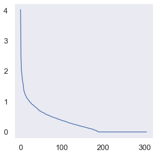

```python
plt.plot(var_exp)
```

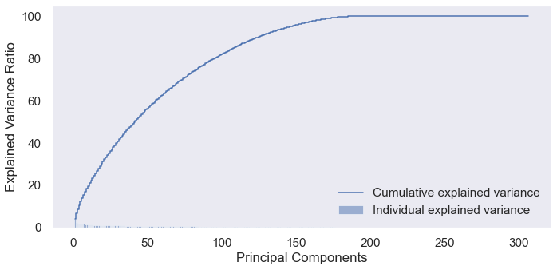

```python
# Ploting
plt.figure(figsize=(10 , 5))
plt.bar(range(1, eig_vals.size + 1), var_exp, alpha = 0.5, align = 'center', label = 'Individual explained variance')
plt.step(range(1, eig_vals.size + 1), cum_var_exp, where='mid', label = 'Cumulative explained variance')
plt.ylabel('Explained Variance Ratio')
plt.xlabel('Principal Components')
plt.legend(loc = 'best')
plt.tight_layout()
plt.show()
```

```python
len(cum_var_exp)
```

```
306
```

```python
# Using scikit learn PCA here. It does all the above steps and maps data to PCA dimensions in one shot
from sklearn.decomposition import PCA

# NOTE - we are generating only 130 PCA dimensions (dimensionality reduction from 306 to 130)
# For 130 components we are getting approximately 90% of the variance
pca = PCA(n_components=130)
data_reduced = pca.fit_transform(x)
data_reduced.transpose()
```

```
array([[ 3.13607723,  1.4683337 ,  1.47377401, ..., -2.29579297,
        -2.9767901 , -2.91689001],
       [-1.18437149, -1.84582532,  0.16893927, ..., -0.95284614,
        -0.84872167,  2.03907734],
       [-0.50572281, -0.29181238,  2.60537928, ..., -1.33348159,
         1.52621731,  2.27432471],
       ...,
       [ 1.09290626, -0.76103501, -0.04860139, ...,  0.60084486,
         0.19088357,  0.11070473],
       [ 0.35667584,  0.6984937 ,  1.19947191, ...,  0.65536811,
        -1.38724657,  0.93545111],
       [ 1.19952374, -0.54251223,  0.49237014, ..., -0.46229193,
         1.1212675 , -0.11542173]])
```

```python
pca.components_
```

```
array([[-0.04832612,  0.00468383,  0.00849431, ..., -0.01816578,
        -0.00246967, -0.05098847],
       [-0.01106854, -0.01568632, -0.00847451, ...,  0.02336148,
        -0.00877508,  0.06735362],
       [-0.03306378,  0.02840785,  0.07343382, ...,  0.01064143,
         0.01987501,  0.05704472],
       ...,
       [ 0.0749057 ,  0.05523537, -0.15592604, ..., -0.024964  ,
         0.05655475, -0.00775085],
       [-0.02582031,  0.00239814, -0.05102842, ...,  0.10082236,
        -0.10842886, -0.15798735],
       [-0.00418862,  0.08340457, -0.03851729, ...,  0.09170043,
        -0.13477027,  0.02967078]])
```

```python
df_comp = pd.DataFrame(pca.components_,columns=list(x))
df_comp.head()
```

|  | 0 | 1 | 2 | 3 | 4 | 5 | 6 | 7 | 8 | 9 | ... | 542 | 543 | 544 | 546 | 547 | 548 | 550 | 558 | 559 | 562 |
| --- | --- | --- | --- | --- | --- | --- | --- | --- | --- | --- | --- | --- | --- | --- | --- | --- | --- | --- | --- | --- | --- |
| 0 | -0.048326 | 0.004684 | 0.008494 | -0.084903 | -0.026246 | 2.032879e-20 | 0.098356 | 0.023238 | 0.078975 | -0.034406 | ... | -0.191614 | -0.136999 | 0.088527 | 0.057265 | 0.092125 | 0.155170 | 0.054977 | -0.018166 | -0.002470 | -0.050988 |
| 1 | -0.011069 | -0.015686 | -0.008475 | -0.038960 | 0.017968 | -2.775558e-17 | 0.044229 | -0.023102 | 0.003445 | -0.012219 | ... | 0.002267 | 0.023610 | 0.026427 | 0.040022 | 0.009082 | -0.050944 | -0.019656 | 0.023361 | -0.008775 | 0.067354 |
| 2 | -0.033064 | 0.028408 | 0.073434 | 0.019890 | 0.044134 | -0.000000e+00 | -0.023200 | -0.038617 | -0.034344 | -0.022651 | ... | -0.013715 | 0.008315 | -0.027352 | -0.069571 | -0.014154 | -0.035065 | 0.063254 | 0.010641 | 0.019875 | 0.057045 |
| 3 | -0.015108 | 0.013261 | -0.090332 | -0.038748 | -0.009895 | -1.040834e-17 | 0.026313 | 0.030058 | 0.035322 | -0.033853 | ... | -0.016808 | 0.040473 | 0.049812 | 0.037378 | 0.022491 | 0.025455 | 0.014449 | -0.052468 | -0.042115 | -0.049355 |
| 4 | 0.017285 | 0.017329 | 0.066807 | 0.040533 | 0.055773 | -1.110223e-16 | -0.059065 | -0.052096 | 0.055585 | 0.005321 | ... | 0.048987 | 0.043965 | 0.076465 | -0.059641 | 0.005033 | 0.007402 | 0.020129 | -0.012924 | 0.010420 | -0.011005 |

5 rows × 306 columns

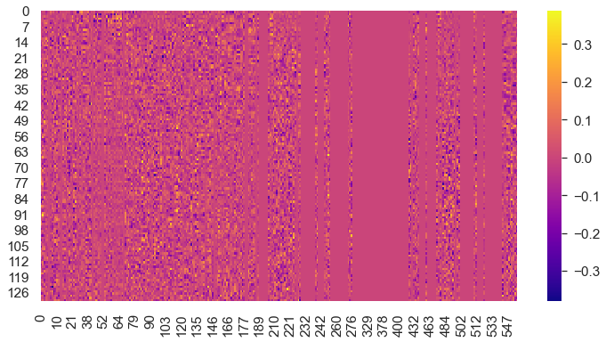

```python
plt.figure(figsize=(12,6))
sns.heatmap(df_comp,cmap='plasma',)
```

```python
data_reduced.shape
```

```
(1567, 130)
```

```python
df_red2 = pd.DataFrame(data_reduced)
df_red2.head()
```

|  | 0 | 1 | 2 | 3 | 4 | 5 | 6 | 7 | 8 | 9 | ... | 120 | 121 | 122 | 123 | 124 | 125 | 126 | 127 | 128 | 129 |
| --- | --- | --- | --- | --- | --- | --- | --- | --- | --- | --- | --- | --- | --- | --- | --- | --- | --- | --- | --- | --- | --- |
| 0 | 3.136077 | -1.184371 | -0.505723 | -0.508131 | -1.145100 | -0.049010 | 0.773965 | 2.806824 | -1.181708 | -3.321390 | ... | 0.079844 | 0.203318 | -0.647119 | -1.009295 | -0.209209 | -1.028868 | -0.266944 | 1.092906 | 0.356676 | 1.199524 |
| 1 | 1.468334 | -1.845825 | -0.291812 | -0.640980 | -0.034450 | -0.915891 | 0.436088 | 3.086178 | -0.676137 | -0.791117 | ... | -1.225832 | 0.985907 | -0.405709 | -0.025415 | -0.133128 | -0.805071 | 0.747446 | -0.761035 | 0.698494 | -0.542512 |
| 2 | 1.473774 | 0.168939 | 2.605379 | -0.099665 | -1.598698 | -0.927351 | -0.080945 | 1.784525 | -1.383216 | 0.580164 | ... | -0.002906 | 1.285491 | 0.680937 | 0.690007 | -0.573880 | 0.999295 | -1.439638 | -0.048601 | 1.199472 | 0.492370 |
| 3 | 3.893125 | -1.104363 | 4.812556 | -0.293040 | -1.216278 | -0.709002 | -2.143662 | -0.041873 | -0.603145 | 1.415276 | ... | 0.816117 | -0.572555 | -1.336291 | -1.736492 | 0.443129 | -2.243284 | 0.001435 | 0.302255 | -0.194344 | -1.505164 |
| 4 | 2.401906 | 2.180039 | 2.123586 | 0.304014 | 2.084057 | 0.215767 | 0.849169 | 0.624920 | -2.453231 | -0.071549 | ... | -1.327654 | 1.304278 | 0.559151 | -0.125543 | -0.408665 | 1.382114 | 0.741923 | -1.409290 | 0.477713 | 0.779836 |

5 rows × 130 columns

```python
df_red3 = df_red2.copy()
df_red4 = df_red3
df_red4["Pass/Fail"] = data["Pass/Fail"]
```

```python
df_red4.shape
```

```
(1567, 131)
```

```python
df_red4.head()
```

|  | 0 | 1 | 2 | 3 | 4 | 5 | 6 | 7 | 8 | 9 | ... | 121 | 122 | 123 | 124 | 125 | 126 | 127 | 128 | 129 | Pass/Fail |
| --- | --- | --- | --- | --- | --- | --- | --- | --- | --- | --- | --- | --- | --- | --- | --- | --- | --- | --- | --- | --- | --- |
| 0 | 3.136077 | -1.184371 | -0.505723 | -0.508131 | -1.145100 | -0.049010 | 0.773965 | 2.806824 | -1.181708 | -3.321390 | ... | 0.203318 | -0.647119 | -1.009295 | -0.209209 | -1.028868 | -0.266944 | 1.092906 | 0.356676 | 1.199524 | -1 |
| 1 | 1.468334 | -1.845825 | -0.291812 | -0.640980 | -0.034450 | -0.915891 | 0.436088 | 3.086178 | -0.676137 | -0.791117 | ... | 0.985907 | -0.405709 | -0.025415 | -0.133128 | -0.805071 | 0.747446 | -0.761035 | 0.698494 | -0.542512 | -1 |
| 2 | 1.473774 | 0.168939 | 2.605379 | -0.099665 | -1.598698 | -0.927351 | -0.080945 | 1.784525 | -1.383216 | 0.580164 | ... | 1.285491 | 0.680937 | 0.690007 | -0.573880 | 0.999295 | -1.439638 | -0.048601 | 1.199472 | 0.492370 | 1 |
| 3 | 3.893125 | -1.104363 | 4.812556 | -0.293040 | -1.216278 | -0.709002 | -2.143662 | -0.041873 | -0.603145 | 1.415276 | ... | -0.572555 | -1.336291 | -1.736492 | 0.443129 | -2.243284 | 0.001435 | 0.302255 | -0.194344 | -1.505164 | -1 |
| 4 | 2.401906 | 2.180039 | 2.123586 | 0.304014 | 2.084057 | 0.215767 | 0.849169 | 0.624920 | -2.453231 | -0.071549 | ... | 1.304278 | 0.559151 | -0.125543 | -0.408665 | 1.382114 | 0.741923 | -1.409290 | 0.477713 | 0.779836 | -1 |

5 rows × 131 columns

```
array([[<AxesSubplot:title={'center':'0'}, xlabel='Pass/Fail'>,
        <AxesSubplot:title={'center':'1'}, xlabel='Pass/Fail'>],
       [<AxesSubplot:title={'center':'2'}, xlabel='Pass/Fail'>,
        <AxesSubplot:title={'center':'3'}, xlabel='Pass/Fail'>],
       [<AxesSubplot:title={'center':'4'}, xlabel='Pass/Fail'>,
        <AxesSubplot:title={'center':'5'}, xlabel='Pass/Fail'>]],
      dtype=object)
```

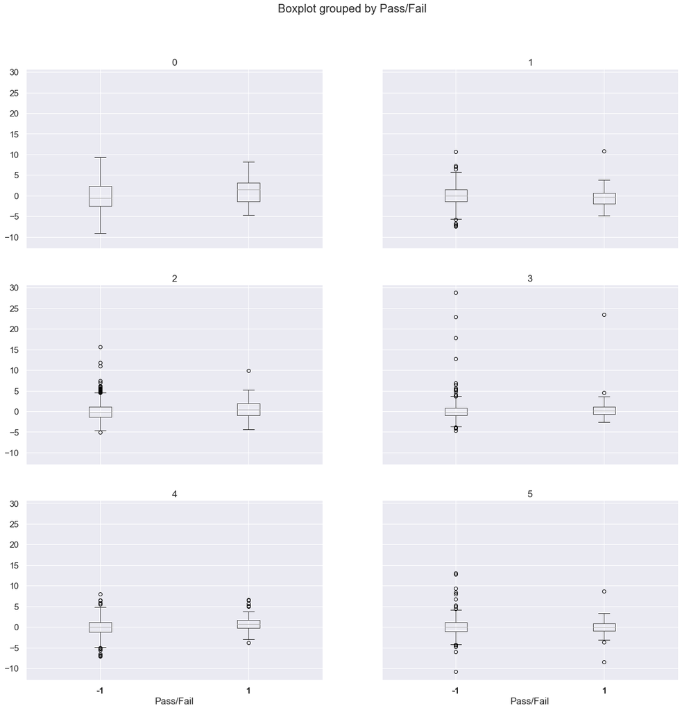

```python
#Sample boxplot shows that there are outliers in the data, let us fix them
df_red4.boxplot(column = [df_red4.columns[0],
                          df_red4.columns[1],
                          df_red4.columns[2],
                          df_red4.columns[3],
                          df_red4.columns[4],
                          df_red4.columns[5],
                         ]
                          , by = 'Pass/Fail', figsize=(20,20))
```

```python
#Create a copy of the dataset for maintain data after outlier removal
#Here after identifying outliers we replace with median
pd_data = df_red4.copy()
#pd_data.head()

#pd_data2 = pd_data.drop(columns=['name'],axis=1)
#pd_data2 = pd_data2.apply(replace,axis=1)
from scipy import stats

#Define a function to remove outliers on max side
def outlier_removal_max(var):
    var = np.where(var > var.quantile(0.75)+ stats.iqr(var),var.quantile(0.50),var)
    return var

#Define a function to remove outliers on min side
def outlier_removal_min(var):
    var = np.where(var < var.quantile(0.25) - stats.iqr(var),var.quantile(0.50),var)
    return var

#Loop over the columns and remove the outliers on min and max side
for column in pd_data:
    pd_data[column] = outlier_removal_max(pd_data[column])
    pd_data[column] = outlier_removal_min(pd_data[column])
```

```
array([[<AxesSubplot:title={'center':'0'}, xlabel='Pass/Fail'>,
        <AxesSubplot:title={'center':'1'}, xlabel='Pass/Fail'>],
       [<AxesSubplot:title={'center':'2'}, xlabel='Pass/Fail'>,
        <AxesSubplot:title={'center':'3'}, xlabel='Pass/Fail'>],
       [<AxesSubplot:title={'center':'4'}, xlabel='Pass/Fail'>,
        <AxesSubplot:title={'center':'5'}, xlabel='Pass/Fail'>]],
      dtype=object)
```

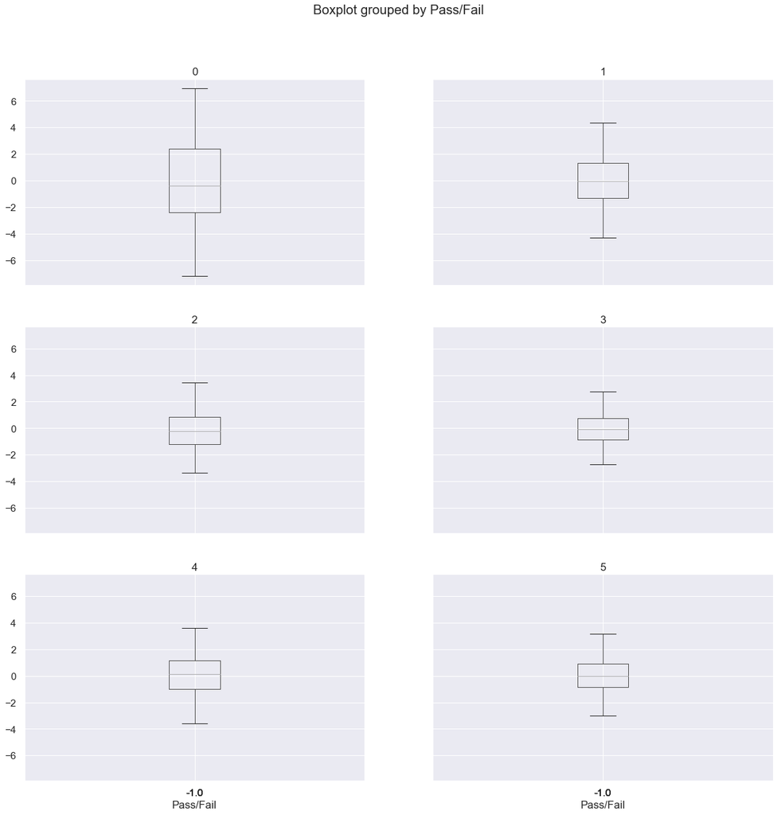

```python
#Sample boxplot shows that outliers are fixed, but we are loosing observations belonging to failure
#class (Pass/Fail = 1) So we should not remove outliers here
pd_data.boxplot( column =[df_red4.columns[0],
                          df_red4.columns[1],
                          df_red4.columns[2],
                          df_red4.columns[3],
                          df_red4.columns[4],
                          df_red4.columns[5],
                         ],by = 'Pass/Fail', figsize=(20,20))
```

```python
# separating the dependent and independent data

x = df_red4.iloc[:, df_red4.columns != 'Pass/Fail']
y = df_red4.iloc[:, df_red4.columns == 'Pass/Fail']

# getting the shapes of new data sets x and y
print("shape of x:", x.shape)
print("shape of y:", y.shape)
```

```
shape of x: (1567, 130)
shape of y: (1567, 1)
```

```python
# Under Sampling - Check how many failure observations are there
# We have 104 such observations

failed_tests = np.array(df_red4[df_red4['Pass/Fail'] == 1].index)
no_failed_tests = len(failed_tests)

print(no_failed_tests)
```

```
104
```

```python
# Check how many pass observations are there
# We have 1,463 such observations

normal_indices = df_red4[df_red4['Pass/Fail'] == -1]
no_normal_indices = len(normal_indices)

print(no_normal_indices)
```

```
1463
```

```python
# Get 104 random observations from the pass class as well

random_normal_indices = np.random.choice(no_normal_indices, size = no_failed_tests, replace = True)
random_normal_indices = np.array(random_normal_indices)

print(len(random_normal_indices))
```

```
104
```

```python
#Getting a 50-50 representation from both pass and fail classes
under_sample = np.concatenate([failed_tests, random_normal_indices])
print(len(under_sample))
```

```
208
```

```python
# creating the undersample data

undersample_data = df_red4.iloc[under_sample, :]

# splitting the undersample dataset into x and y sets

x = undersample_data.iloc[:, undersample_data.columns != 'Pass/Fail']
y = undersample_data.iloc[:, undersample_data.columns == 'Pass/Fail']

print(x.shape)
print(y.shape)
```

```
(208, 130)
(208, 1)
```

```python
from sklearn.model_selection import train_test_split

x_train_us, x_test_us, y_train_us, y_test_us = train_test_split(x, y, test_size = 0.3, random_state = 1)

print(x_train_us.shape)
print(y_train_us.shape)
print(x_test_us.shape)
print(y_test_us.shape)
```

```
(145, 130)
(145, 1)
(63, 130)
(63, 1)
```

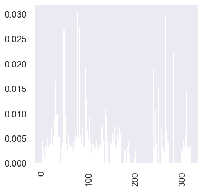

```python
importance = model.feature_importances_
# summarize feature importance
# plot feature importance
pyplot.bar([x for x in range(len(importance))], importance)
plt.xticks(rotation=90)
pyplot.show()
```

```python
feature_df = pd.DataFrame(importance, index=X_train.columns)
feature_df.shape
```

```
(317, 1)
```

```python
df_final = data.drop(['Pass/Fail'], axis=1)
target = data['Pass/Fail']
```

```python
# split data into train subset and test subset
X_train, X_test, y_train, y_test = train_test_split(df_final, target, test_size=0.3, random_state=42, stratify=target )
```

```python
# standardization

from sklearn.preprocessing import StandardScaler

# creating a standard scaler
sc = StandardScaler()

# fitting independent data to the model
x_train_std = sc.fit_transform(X_train)
x_test_std = sc.transform(X_test)
```

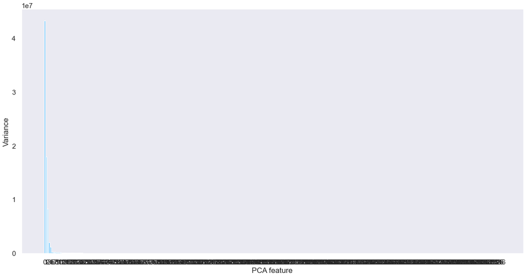

```python
from sklearn.decomposition import PCA
pca = PCA(random_state=123)

pca.fit(df_final)

features = range(pca.n_components_)

plt.figure(figsize=(20,10))
plt.bar(features, pca.explained_variance_, color='lightskyblue')
plt.xlabel('PCA feature')
plt.ylabel('Variance')
plt.xticks(features)
plt.show()
```

```python
from sklearn.decomposition import PCA


pca = PCA(n_components=50) # taking 50 component
data_reduced = pca.fit_transform(x_train_std)
data_test = pca.transform(x_test_std)
```

```python
model = RandomForestClassifier(n_estimators= 50, criterion= 'gini', max_depth= 100)
model.fit(data_reduced, y_train)

y_pred_rf = model.predict(data_test)

print('accuracy score', accuracy_score(y_pred_rf, y_test))
print('confusion_matrix', confusion_matrix(y_pred_rf, y_test))
print('precision_score', average_precision_score(y_pred_rf, y_test))
```

```
accuracy score 0.9299363057324841
confusion_matrix [[438  31]
 [  2   0]]
precision_score 0.004246284501061571
```

```python
# KNN - choosing the K value
from sklearn.neighbors import KNeighborsClassifier
from sklearn.metrics import accuracy_score
myList = list(range(2,15))

neighbors = KNeighborsClassifier()

ac_scores = []

# perform accuracy metrics for values from 1,3,5....19
for k in myList:
  knn = KNeighborsClassifier(n_neighbors=k)
  knn.fit(x_train_sc, y_train_res)
  y_pred = knn.predict(x_test_sc)
  scores = accuracy_score(y_test, y_pred)
  ac_scores.append(scores)
  MSE = [1 - x for x in ac_scores]
  optimal_k = myList[MSE.index(min(MSE))]
print("The optimal number of neighbors is %d" % optimal_k)
```

```
The optimal number of neighbors is 2
```

```python
from sklearn.neighbors import KNeighborsClassifier
knn = KNeighborsClassifier(n_neighbors=2)

knn.fit(x_train_sc, y_train_res)

y_pred_knn = knn.predict(x_test_sc)

print('accuracy score', accuracy_score(y_pred_knn, y_test))
cm = confusion_matrix(y_pred_knn, y_test)
cm
```

```
accuracy score 0.5138004246284501
```

```
array([[220,   9],
       [220,  22]], dtype=int64)
```

```python
#### Gradient boosting
```

```python
from sklearn.ensemble import GradientBoostingClassifier

gb = GradientBoostingClassifier(n_estimators=100, learning_rate=1.0, max_depth=100, random_state=0)

gb.fit(x_train_sc, y_train_res)

y_pred_gb = gb.predict(x_test_sc)

print('accuracy score', accuracy_score(y_pred_gb, y_test))
cm = confusion_matrix(y_pred_gb, y_test)
```

```
accuracy score 0.8450106157112527
```

```python
from sklearn.model_selection import GridSearchCV
from sklearn.metrics import classification_report

model = GradientBoostingClassifier(n_estimators= 100)

# making a parameters list
parameters = {
    'max_depth' : [10, 50],
    'max_features' : [5,10]}

# making a grid search model
grid_search = GridSearchCV(estimator = model, param_grid = parameters, scoring = 'f1', cv = 3, n_jobs = -1)
grid_search = grid_search.fit(x_train_sc, y_train_res)

# getting the results
best_accuracy = grid_search.best_score_
best_parameters = grid_search.best_params_

predictions = grid_search.predict(x_test_sc)

print("Best Accuracy: ", best_accuracy)
print("Best Parameter: ", best_parameters)
print(classification_report(y_test, predictions))
```

```
Best Accuracy:  0.9936178557033096
Best Parameter:  {'max_depth': 10, 'max_features': 5}
              precision    recall  f1-score   support

          -1       0.93      1.00      0.96       440
           1       0.00      0.00      0.00        31

    accuracy                           0.93       471
   macro avg       0.47      0.50      0.48       471
weighted avg       0.87      0.93      0.90       471
```

```
                                    6.Post Training and Conclusion:
```

#### B.Select the final best trained model along with your detailed comments for selecting this model.

#### C.Pickle the selected model for future use.

#### D.Write your conclusion on the results.

```python
from sklearn.decomposition import PCA


pca = PCA(n_components=50) # taking 50 component
data_reduced = pca.fit_transform(x_train_std)
data_test = pca.transform(x_test_std)
```

```python
model = RandomForestClassifier(n_estimators= 50, criterion= 'gini', max_depth= 100)
model.fit(data_reduced, y_train)

y_pred_rf = model.predict(data_test)

print('accuracy score', accuracy_score(y_pred_rf, y_test))
print('confusion_matrix', confusion_matrix(y_pred_rf, y_test))
print('precision_score', average_precision_score(y_pred_rf, y_test))
```

```
accuracy score 0.9299363057324841
confusion_matrix [[438  31]
 [  2   0]]
precision_score 0.004246284501061571
```

```python
# KNN - choosing the K value
from sklearn.metrics import accuracy_score
myList = list(range(2,15))

neighbors = KNeighborsClassifier()

ac_scores = []

# perform accuracy metrics for values from 1,3,5....19
for k in myList:
  knn = KNeighborsClassifier(n_neighbors=k)
  knn.fit(x_train_sc, y_train_res)
  y_pred = knn.predict(x_test_sc)
  scores = accuracy_score(y_test, y_pred)
  ac_scores.append(scores)
  MSE = [1 - x for x in ac_scores]
  optimal_k = myList[MSE.index(min(MSE))]
print("The optimal number of neighbors is %d" % optimal_k)
```

```
The optimal number of neighbors is 2
```

```python
from sklearn.neighbors import KNeighborsClassifier
knn = KNeighborsClassifier(n_neighbors=2)

knn.fit(x_train_sc, y_train_res)

y_pred_knn = knn.predict(x_test_sc)

print('accuracy score', accuracy_score(y_pred_knn, y_test))
cm = confusion_matrix(y_pred_knn, y_test)
cm
```

```
accuracy score 0.5138004246284501
```

```
array([[220,   9],
       [220,  22]], dtype=int64)
```

```python
from sklearn.ensemble import GradientBoostingClassifier

gb = GradientBoostingClassifier(n_estimators=100, learning_rate=1.0, max_depth=100, random_state=0)

gb.fit(x_train_sc, y_train_res)

y_pred_gb = gb.predict(x_test_sc)

print('accuracy score', accuracy_score(y_pred_gb, y_test))
cm = confusion_matrix(y_pred_gb, y_test)
cm
```

```
accuracy score 0.8450106157112527
```

```
array([[390,  23],
       [ 50,   8]], dtype=int64)
```

```python
from sklearn.model_selection import GridSearchCV
from sklearn.metrics import classification_report

model = GradientBoostingClassifier(n_estimators= 100)

# making a parameters list
parameters = {
    'max_depth' : [10, 50],
    'max_features' : [5,10]}

# making a grid search model
grid_search = GridSearchCV(estimator = model, param_grid = parameters, scoring = 'f1', cv = 3, n_jobs = -1)
grid_search = grid_search.fit(x_train_sc, y_train_res)

# getting the results
best_accuracy = grid_search.best_score_
best_parameters = grid_search.best_params_

predictions = grid_search.predict(x_test_sc)

print("Best Accuracy: ", best_accuracy)
print("Best Parameter: ", best_parameters)
print(classification_report(y_test, predictions))
```

```
Best Accuracy:  0.9940956243036952
Best Parameter:  {'max_depth': 10, 'max_features': 10}
              precision    recall  f1-score   support

          -1       0.93      1.00      0.97       440
           1       0.00      0.00      0.00        31

    accuracy                           0.93       471
   macro avg       0.47      0.50      0.48       471
weighted avg       0.87      0.93      0.90       471
```

```python
import pickle

# Save the trained model as a pickle string.
saved_model = pickle.dumps(lr)
```

```python
# Load the pickled model

model_from_pickle = pickle.loads(saved_model)

# Use the loaded pickled model to make predictions
pred = model_from_pickle.predict(x_test_sc)
```

```python
# Load the pickled model

model_from_pickle = pickle.loads(saved_model)

# Use the loaded pickled model to make predictions
pred = model_from_pickle.predict(x_test_sc)
```

```python
# evaluating the model
# printing the confusion matrix
cm = confusion_matrix(y_test, pred)
cm
```

```
array([[334, 106],
       [ 18,  13]], dtype=int64)
```

We have tried multiple models and Local Outlier Factor for the imbalanced classes.Across methods OneClassSVM performed the worst while Local Outlier Factor performed the best in terms of recall accuracy¶ We saw that for imbalanced classes accuracy and recall are invertially proportional to each other. Better recall models have lower accuracy and vice versa.. We used grid search for selecting the best hyperparamets #### Detailed suggestions or improvements or on quality, quantity, variety, velocity, veracity etc. on the data points collected by the bank to perform a better data analysis in future. - We can use forward selection or backward elimination for selecting relevant features - We require more data points as there are many features - We can try multiple ways to balance the target class - We can try PCA to reduce number of features